# Bringing Geographical Data to Life: Usage of Chloropleth Maps

```r
# Use our base map of the United States generated above, and then add another
# layer to it using geom_polygon. Use our 'joined' data frame as the data to be used,
# set 'fill' to the variable you want to analyze, and and then use the 'scale_fill_gradient' # function to pick your colors.
funding_map <- us + geom_polygon(data = joined, aes(x = long, y = lat ,group = group, fill = dollars), color = "yellow") + scale_fill_gradient(low = "white", high = "blue", name = 'Dollars/Student
        (1000s)') + ggtitle('Funding Per High School Student ($1000s)')

# Apply this same mapping process to the other two variables.

take_map <- us + geom_polygon(data = joined, aes(x = long, y = lat, group = group, fill = percent), color = "yellow") + scale_fill_gradient(low = "white", high = "blue", name = '% Take SAT') + ggtitle('Percent of Students Who Take SAT')

score_map <- us + geom_polygon(data = joined, aes(x = long, y = lat, group = group, fill = SAT), color = "yellow") + scale_fill_gradient(low = "white", high = "blue", name = 'SAT Score') + ggtitle('SAT Scores')
```

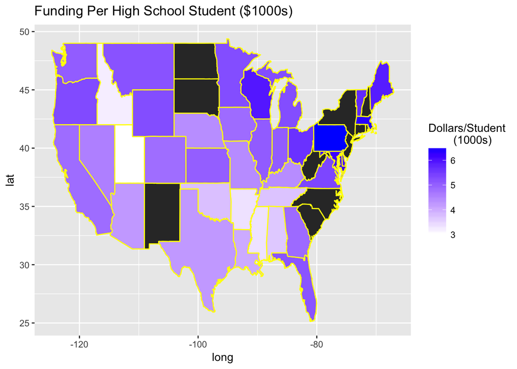

```r
funding_map
```

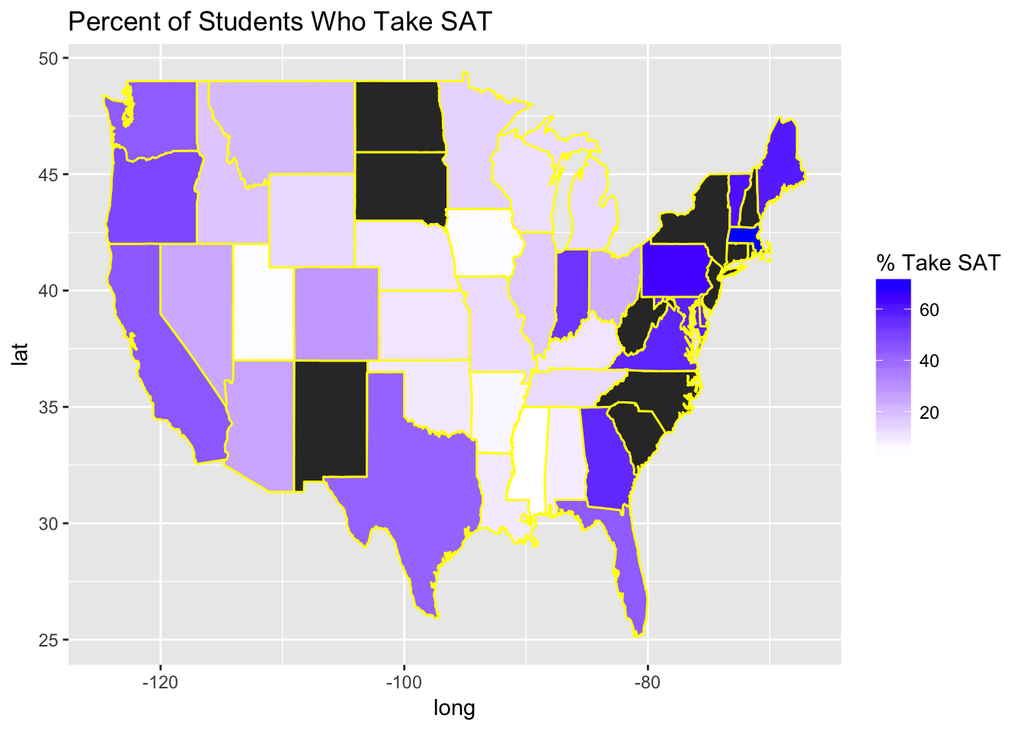

```r
take_map
```

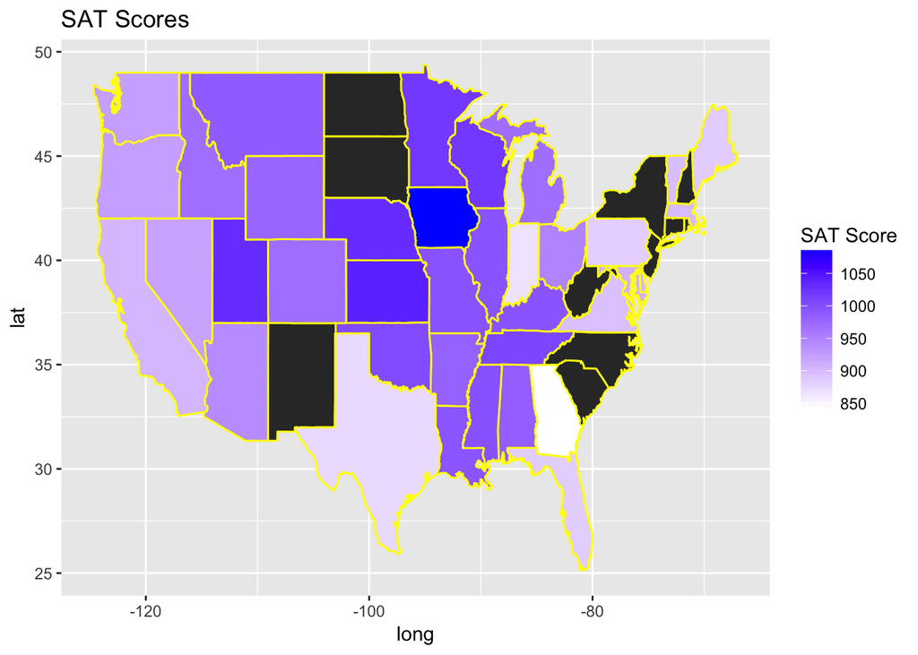

```r
score_map
```

# Discussion

# Conclusion and Take Home Message

I’m impressed with the mapping abilities that R provides, especially with packages that we have some familiarity with from this class. While the main driver to producing the actual visualization is ggplot2, the maps package is integral to supplying the data required to make the visualization.

Chloropleth maps are generally intuitive to read for most people, and knowing how to create one in R should prove useful if you ever have to visualize data over a geographic region. Visualizations of data such as this one are powerful in that it allows one to present a large amount of data in a quick manner, and can also help prove a point better than just displaying someone numbers.

Remember that you’re not just limited to generating chloropleth maps of the United States - you can apply this same methodology to any geographic region! I hope that you found this post useful and are able to utilize it in your life and or career at some point.

# References

Chlorpleth Map - https://en.wikipedia.org/wiki/Choropleth_map

Making Maps in R - https://cengel.github.io/rspatial/4_Mapping.nb.html

How to Make Chloropleth Maps with R - http://bl.ocks.org/prabhasp/raw/5030005/

Geographic Visualizations with R’s ggmaps -https://blog.dominodatalab.com/geographic-visualization-with-rs-ggmaps/

ggmaps package - https://journal.r-project.org/archive/2013-1/kahle-wickham.pdf

Education Data - https://raw.githubusercontent.com/vincentarelbundock/Rdatasets/master/csv/car/States.csv

Mapping in R - http://eriqande.github.io/rep-res-web/lectures/making-maps-with-R.html